# Data Wrangling Activity

We are going to look at more transportation data, this time from the city of Chicago. We want to see information on the daily ridership of CTA stations.

```r
url <- "https://data.cityofchicago.org/api/views/5neh-572f/rows.csv?accessType=DOWNLOAD&bom=true&format=true"

all_stations_raw <- read_csv(url)
```

## Column Actions

Taking a look at the data, there are a few columns we need to figure out how to deal with. First, we can convert `date` from text date to date-time data. Then we can drop the station ID, then we can turn the `daytype` variable into a factor with three levels (“weekday”, “saturday”, “sunday/holiday”).

```r
all_stations <- all_stations_raw %>%
  # Step 2: get columns and rename stationname
  select(station = stationname, date, rides, day_type = daytype) %>%
  # Step 3: Convert the character date field to a date encoding.
  # This uses the "lubridate" package
  # Also, put the data in units of 1K rides
  # Convert day_type to a factor and rename the levels
  mutate(
    date = mdy(date),
    rides = rides / 1000,
    day_type = recode(
      as.factor(day_type),
      "W" = "weekday", "A" = "saturday", "U" = "sunday/holiday"
      )
    )
```

Column actions can also help us select all columns whose names have a certain pattern, e.g., `starts_with`. Here we select all variables of character type:

```r
all_stations %>%
  select(where(is.character))
```

```
## # A tibble: 1,245,839 × 1
##    station
##    <chr>
##  1 Jefferson Park
##  2 Cermak-Chinatown
##  3 Central-Lake
##  4 Dempster-Skokie
##  5 Dempster
##  6 Lake/State
##  7 Oak Park-Forest Park
##  8 Kedzie-Homan-Forest Park
##  9 35th/Archer
## 10 Addison-North Main
## # ℹ 1,245,829 more rows
```

### Let’s talk about piping!

The pipe operator (either `%>%` or `|>`) is nice way to nest operations in a readable way. The pipe operator takes what is on the left of the pipe, and uses (*pipes*) it to the first argument of what is on the right.

For instance, the following two pieces of code are equivalent:

```r
# with pipe
all_stations %>%
  mutate(month = month(date)) %>%
  glimpse()
```

```
## Rows: 1,245,839
## Columns: 5
## $ station  <chr> "Jefferson Park", "Cermak-Chinatown", "Central-Lake", "Dempst…
## $ date     <date> 2017-12-22, 2017-12-18, 2017-12-02, 2017-12-19, 2017-12-03, …
## $ rides    <dbl> 6.104, 3.636, 1.270, 1.759, 0.499, 8.615, 0.442, 1.353, 3.353…
## $ day_type <fct> weekday, weekday, saturday, weekday, sunday/holiday, saturday…
## $ month    <dbl> 12, 12, 12, 12, 12, 12, 12, 12, 12, 12, 12, 12, 12, 12, 12, 1…
```

```r
#no pipe
glimpse( mutate(all_stations, month = month(date)) )
```

```
## Rows: 1,245,839
## Columns: 5
## $ station  <chr> "Jefferson Park", "Cermak-Chinatown", "Central-Lake", "Dempst…
## $ date     <date> 2017-12-22, 2017-12-18, 2017-12-02, 2017-12-19, 2017-12-03, …
## $ rides    <dbl> 6.104, 3.636, 1.270, 1.759, 0.499, 8.615, 0.442, 1.353, 3.353…
## $ day_type <fct> weekday, weekday, saturday, weekday, sunday/holiday, saturday…
## $ month    <dbl> 12, 12, 12, 12, 12, 12, 12, 12, 12, 12, 12, 12, 12, 12, 12, 1…
```

If you look at the help file for `glimpse` and `mutate`, both take a data frame as the first argument.

Finally, pipes interact nicely with some summary functions like this helpful `skim` function from the `skimr` package.

```r
library(skimr)
all_stations |>
  skim()
```

Data summary

| Name | all_stations |
| --- | --- |
| Number of rows | 1245839 |
| Number of columns | 4 |
| _______________________ |  |
| Column type frequency: |  |
| character | 1 |
| Date | 1 |
| factor | 1 |
| numeric | 1 |
| ________________________ |  |
| Group variables | None |

**Variable type: character**

| skim_variable | n_missing | complete_rate | min | max | empty | n_unique | whitespace |
| --- | --- | --- | --- | --- | --- | --- | --- |
| station | 0 | 1 | 4 | 24 | 0 | 149 | 0 |

**Variable type: Date**

| skim_variable | n_missing | complete_rate | min | max | median | n_unique |
| --- | --- | --- | --- | --- | --- | --- |
| date | 0 | 1 | 2001-01-01 | 2024-11-30 | 2013-01-07 | 8735 |

**Variable type: factor**

| skim_variable | n_missing | complete_rate | ordered | n_unique | top_counts |
| --- | --- | --- | --- | --- | --- |
| day_type | 0 | 1 | FALSE | 3 | wee: 870145, sun: 198256, sat: 177438 |

**Variable type: numeric**

| skim_variable | n_missing | complete_rate | mean | sd | p0 | p25 | p50 | p75 | p100 | hist |
| --- | --- | --- | --- | --- | --- | --- | --- | --- | --- | --- |
| rides | 0 | 1 | 2.97 | 3.05 | 0 | 0.93 | 1.93 | 3.91 | 36.32 | ▇▁▁▁▁ |

## Row Actions

Row actions enable us to subset the rows. The most common function here is the filter function.

```r
all_stations %>%
  filter(day_type == "sunday/holiday")
```

```
## # A tibble: 198,256 × 4
##    station              date       rides day_type
##    <chr>                <date>     <dbl> <fct>
##  1 Dempster             2017-12-03 0.499 sunday/holiday
##  2 Oak Park-Forest Park 2017-12-17 0.442 sunday/holiday
##  3 Austin-Forest Park   2017-12-03 0.641 sunday/holiday
##  4 Clinton-Lake         2017-12-31 0.621 sunday/holiday
##  5 Randolph/Wabash      2017-12-25 0     sunday/holiday
##  6 Dempster             2017-12-24 0.326 sunday/holiday
##  7 Morse                2017-12-31 2.49  sunday/holiday
##  8 69th                 2017-12-31 2.44  sunday/holiday
##  9 Paulina              2017-12-10 1.00  sunday/holiday
## 10 Kimball              2017-12-31 1.46  sunday/holiday
## # ℹ 198,246 more rows
```

To filter on more than one condition, we can use `&` (and) or `|` (or). An `&` statement will be true only if both sides of the statement are true, and an `|` statement is true if *either* side is true:

```r
print(TRUE & FALSE)
```

```
## [1] FALSE
```

```r
print(TRUE & TRUE)
```

```
## [1] TRUE
```

```r
print(FALSE | TRUE)
```

```
## [1] TRUE
```

```r
all_stations %>%
  filter(day_type == "weekday" | year(date) >= 2020)
```

```
## # A tibble: 947,697 × 4
##    station                 date        rides day_type
##    <chr>                   <date>      <dbl> <fct>
##  1 Jefferson Park          2017-12-22  6.10  weekday
##  2 Cermak-Chinatown        2017-12-18  3.64  weekday
##  3 Dempster-Skokie         2017-12-19  1.76  weekday
##  4 35th/Archer             2017-12-07  3.35  weekday
##  5 Addison-North Main      2017-12-19  6.03  weekday
##  6 Chicago/State           2017-12-27  9.64  weekday
##  7 Wellington              2017-12-07  3.21  weekday
##  8 East 63rd-Cottage Grove 2017-12-26  0.613 weekday
##  9 Grand/State             2017-12-21 10.7   weekday
## 10 Wilson                  2017-12-22  4.86  weekday
## # ℹ 947,687 more rows
```

```r
all_stations %>%
  arrange(desc(rides)) %>%
  head()
```

```
## # A tibble: 6 × 4
##   station            date       rides day_type
##   <chr>              <date>     <dbl> <fct>
## 1 Belmont-North Main 2015-06-28  36.3 sunday/holiday
## 2 Belmont-North Main 2012-06-24  36.0 sunday/holiday
## 3 Lake/State         2016-11-04  35.8 weekday
## 4 Belmont-North Main 2011-06-26  33.8 sunday/holiday
## 5 Addison-North Main 2016-10-29  33.6 saturday
## 6 Belmont-North Main 2013-06-30  30.5 sunday/holiday
```

## Operations on groups

```r
all_stations %>%
  group_by(date) %>%
  #compute two new vars: total_rides to count up all the rides in each group, and num to see how big each group is
  summarize(total_rides = sum(rides), num = n())
```

```
## # A tibble: 8,735 × 3
##    date       total_rides   num
##    <date>           <dbl> <int>
##  1 2001-01-01        106.   141
##  2 2001-01-02        419.   141
##  3 2001-01-03        448.   141
##  4 2001-01-04        459.   141
##  5 2001-01-05        466.   141
##  6 2001-01-06        213.   141
##  7 2001-01-07        142.   141
##  8 2001-01-08        493.   141
##  9 2001-01-09        501.   141
## 10 2001-01-10        503.   141
## # ℹ 8,725 more rows
```

Read the book to find other helpful functions to use within summarize, e.g. to calculate the mean, standard deviation, etc.

### Saving the result of the pipe

Notice that all of these actions didn’t change the data frame! If we want to save the results, we have to assign the result to a new variable using the assignment operator `<-`.

## Putting it all together

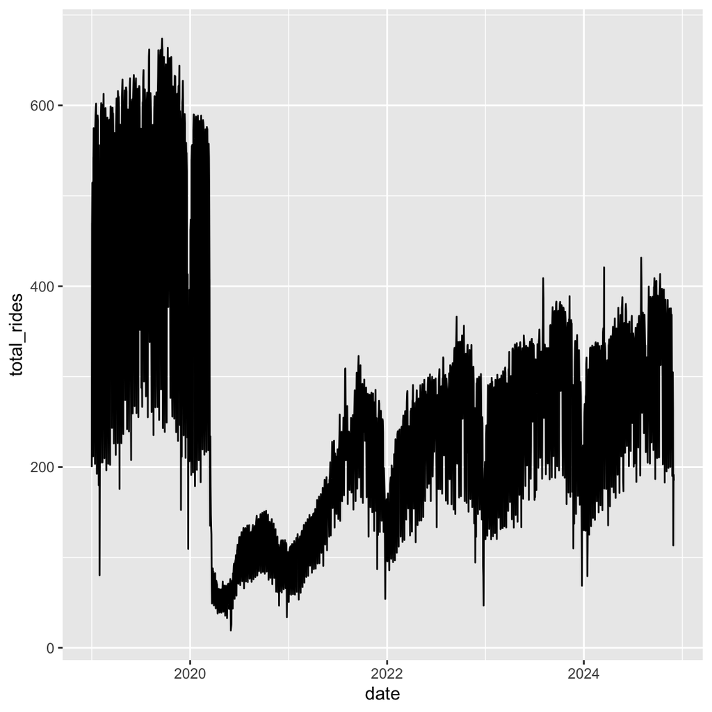

```r
all_stations %>%
  filter(year(date) > 2018) %>%
  group_by(date) %>%
  summarize(total_rides = sum(rides)) %>%
  ggplot(aes(x=date, y=total_rides)) +
  geom_line()
```

This isn’t very nice to look at! That’s because there are $(current\_year - 2018) \times 365$ days to plot on here. Let’s see if we can use our skills to get information on weekly ridership. Here’s an extra variable to get you started, which gives the week number of the year and the year.

```r
all_stations <- all_stations %>%
   mutate(
    week = isoweek(date),
    year = year(date)
  )
```

What do you notice on your plot? How do you explain the patterns you are seeing. Are there any deficiencies in this method for finding weekly ridership, and can you think of any better ways to go? Talk to your group, and let me know what you think!

You should get something like this:

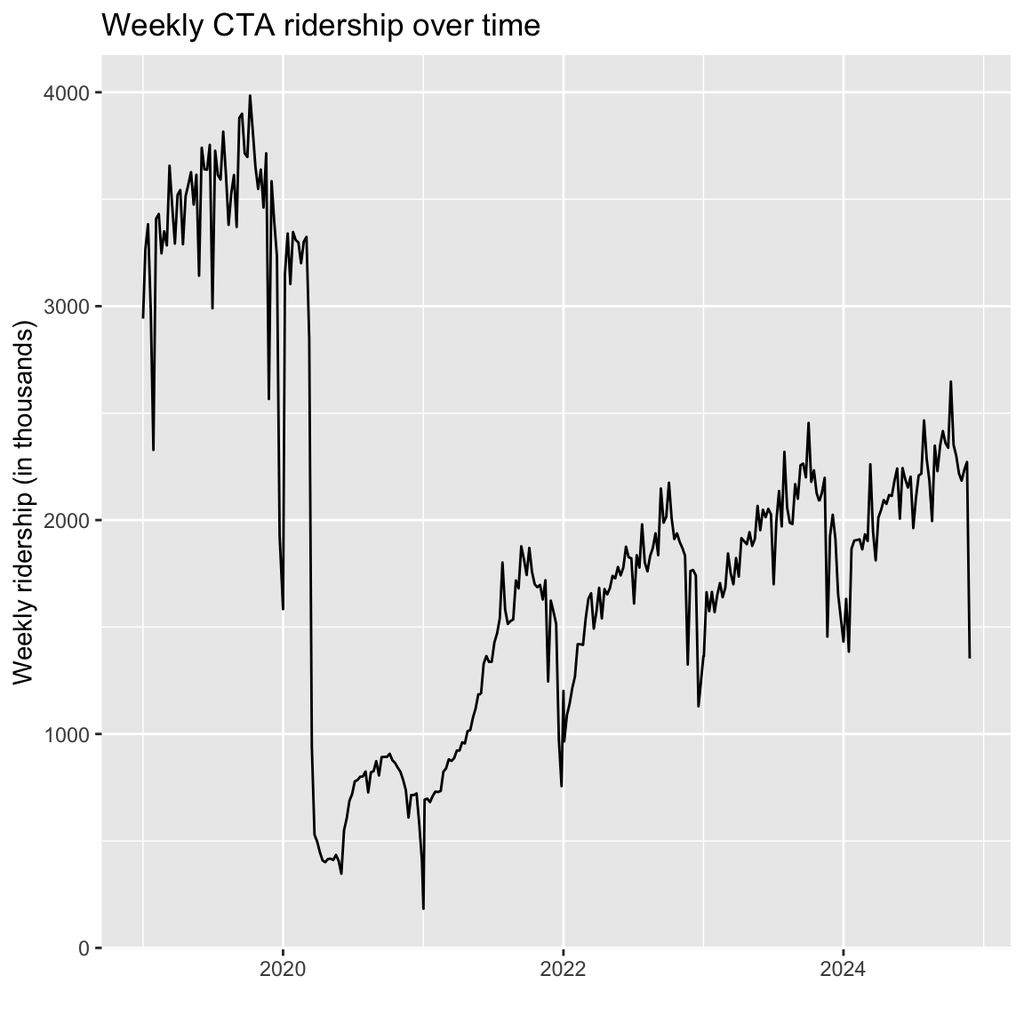